# R FAQ and Common Errors

This document contains answers to questions that students frequently ask while learning how to use R and R Markdown. You can use `Ctrl-F` to search, or the navigation panel on the left-side of this page to browse by topic.

# Importing and Saving Data

### Using “Import Dataset”

**Question**:

Why do I need to write code to load my data? Can’t I just use the “Import Dataset” button in the Environment panel instead?

**Answer**:

Point-click menus don’t allow others to reproduce your actions with gauranteed accuracy. To ensure that your work is fully reproducible you should use executable `R` commands to document your work from start-to-finish.

### read.csv versus read_csv

**Question**:

Is there a difference between `read.csv` and `read_csv`? Which one should I use?

**Answer**:

`read_csv` is a faster way to read .csv files implemented in the `readr` package. If you are reading a very large .csv it can be approximately 5x faster than `read.csv`, but in most cases this extra speed isn’t noticable.

There are also a few differences in how these functions operate:

1. `read_csv` stores headers differently than `read.csv`, so the column names of your data.frame might differ there are certain characters in your data’s variable names.
2. `read_csv` stores any variable containing non-numeric characters as type “character”, whereas `read.csv` stores these variables as type “factor”. See character versus factor variables

**Example**:

```r
library(readr)
mydata2 <- read_csv(file = "https://remiller1450.github.io/data/PoliceKillings.csv")
class(mydata2$name)
```

```
## [1] "character"
```

```r
mydata <- read.csv(file = "https://remiller1450.github.io/data/PoliceKillings.csv")
class(mydata$name)
```

```
## [1] "factor"
```

### Excel files

**Question**:

My data is an excel file and not a .csv, how can I read it into `R`?

**Answer**:

You can use the `read_excel` file in the `readxl` package, which operates similarly to `read_csv` (so you should be aware of the differences between `read.csv` and `read_csv` documented in the previous question).

### Saving cleaned data

**Question**:

My data cleaning script takes a long time, should I save my cleaned data? How should I save it?

**Answer**:

Yes, you should save your cleaned data, you should also keep the `R` code used to clean your raw data. At the end of your data processing code use the `write.csv` file to save your cleaned dataset. Keeping your raw data, a data cleaning script, a clean dataset, and analysis script ensures your work is fully reproducible, but also allows for yourself or others not interested in the long data cleaning process to jump straight to your analyses.

**Example**:

```r
## Load the raw data
data <- read.csv("https://remiller1450.github.io/data/CollegeData.csv")

## Clean the data
iowa_colleges <- data[data$STABBR == "IA", ]

## Export a .csv of the data.frame "iowa_colleges" named clean_college_data to the H-drive
write.csv(iowa_colleges, file = "H:/clean_college_data.csv")
```

### .RData workspace

**Question**:

Why does `RStudio` ask me to save my .RData workspace? And why should I use `write.csv` rather than just saving my .RData workspace?

**Answer**:

Saving your .RData will store everything in your current environment, which usually includes a lot of intermediate objects that aren’t relevant to your final analysis. Having these intermediate objects in your environment can make it difficult to determine whether your code actually reproduces your analysis.

This lack of reproducibility can also lead to errors when knitting .Rmd files. If you ever ran commands out of order, or deleted commands without deleting the objects they create, your code will appear to work when you have your .RData loaded; but knitting your .Rmd file occurs in a clean environment (without your .RData).

You should avoid saving your .RData workspace and instead save important objects using functions like `write.csv`. It is also good practice to clear your environment (use the broom icon in the environment panel of `Rstudio`) each time you begin or resume work on a project.

# Missing Data

### Reading in missing values

**Question**:

How does `R` read missing data? What if my raw data uses a certain code for missing values?

**Answer**:

By default, functions like `read.csv` read any empty cells in your raw data as missing values, which are stored as `NA` in `R`. If your raw data has missing values coded differently you use use the `na.strings` argument in `read.csv` (or `read_csv`/`read_excel`) to tell `R` which values should be interpretted as missing.

**Example**:

```r
## This will read cells that are empty, cells with a period, and cells with the text "N-A" as missing values (NA's)
read.csv("H:/my_data_file.csv", na.strings=c("",".","N-A"))
```

### Working with missing data

**Question**:

What should I do about missing data? Can I still analyze data with missing values?

**Answer**:

Many functions in `R` will not allow any missing data, though some functions (like `lm`) will automatically remove any rows with missing values.

Generally speaking, discarding any observations with missing values may be bias your results. Nevertheless, a widely used approach is to remove the offending rows if the amount of missing data is relatively small. Sample code demonstrating how to remove missing values is shown below:

**Example**:

```r
mydata <- read.csv(file = "https://remiller1450.github.io/data/PoliceKillings.csv")

## complete.ids is a logical vector with 'n' elements that is:
## TRUE if a row contains no missing values (a "complete case")
## FALSE if a row contains at least one missing value
complete.ids <- complete.cases(mydata)

## Use subsetting to keep only the complete cases
completedata <- mydata[complete.ids,]

## In this example 6 cases had missing data
dim(mydata)
```

```
## [1] 467  19
```

```r
dim(completedata)
```

```
## [1] 461  19
```

# Variable Types

### “character” versus “factor” variables?

**Question**:

What is the difference between a “character” variable and a “factor” variable? They look the same…

**Answer**:

Factor variables are categorical variables with pre-defined levels (categories), whereas character variables can be any character string. Many functions will treat these variables interchangeably, but some data manipulation functions will not (see the examples below).

```r
library(readr)
char <- c("$1,000", "$2,000", "$1,000")
fact <- factor(char)

as.numeric(char)   # This produces an error
```

```
## [1] NA NA NA
```

```r
as.numeric(fact)   # This maps to the integers
```

```
## [1] 1 2 1
```

```r
parse_number(char) # This works
```

```
## [1] 1000 2000 1000
```

```r
parse_number(fact) # This also works
```

```
## [1] 1000 2000 1000
```

### R thinks my numeric variable is a “factor”?

**Question**:

`R` considers my numeric variable to be a “factor” and `as.numeric` doesn’t seem to work, what’s wrong?

**Answer**:

Any variable containing non-numeric characters is stored as a “factor” (`R`’s name for categorical variables) when your data is read in. Entries with commas or dollar signs will cause that variable to be stored as a factor. How missing values are coded in your data may also lead to a factor desigination.

For factor variables, `as.numeric` will map the levels of the factor to the integers, meaning the first level (`R`’s name for category) is mapped to 1, the second level is mapped to 2, etc. Very often you can fix this problem by coercing the factor variable to type “character” and then using the `parse_number` function in the `readr` package. See the code below for an example:

```r
library(readr)
salaries <- factor(c("80,000", "93,000", "78,000"))
as.numeric(salaries) # Doesn't work
```

```
## [1] 2 3 1
```

```r
parse_number(as.character(salaries)) # Works
```

```
## [1] 80000 93000 78000
```

### Renaming the categories of a factor variable

**Question**:

How can I change the category names of a factor variable?

**Answer**:

The categories of a factor are called levels, you can assign your own labels to overwrite the current ones using the `levels` function and the assignment operator `<-` (see the example below).

```r
x <- as.factor(c("USA","UK","USA"))
levels(x) <- c("United Kingdom", "United States")
x
```

```
## [1] United States  United Kingdom United States
## Levels: United Kingdom United States
```

### Reordering the categories of a factor variable

**Question**:

How can I re-order the categories of a factor variable?

**Answer**:

By default `R` orders the levels of a factor variable alphabetically. You can change using the `factor` function and providing the levels yourself via the `levels` argument (see the example below).

```r
x <- as.factor(c("USA","UK","USA"))
x
```

```
## [1] USA UK  USA
## Levels: UK USA
```

```r
y <- factor(x, levels = c("USA", "UK"))
y
```

```
## [1] USA UK  USA
## Levels: USA UK
```

Sometimes when creating graphs you might want categories to be in ascending/descending order defined by another criteria. The code below provides an example how to do this:

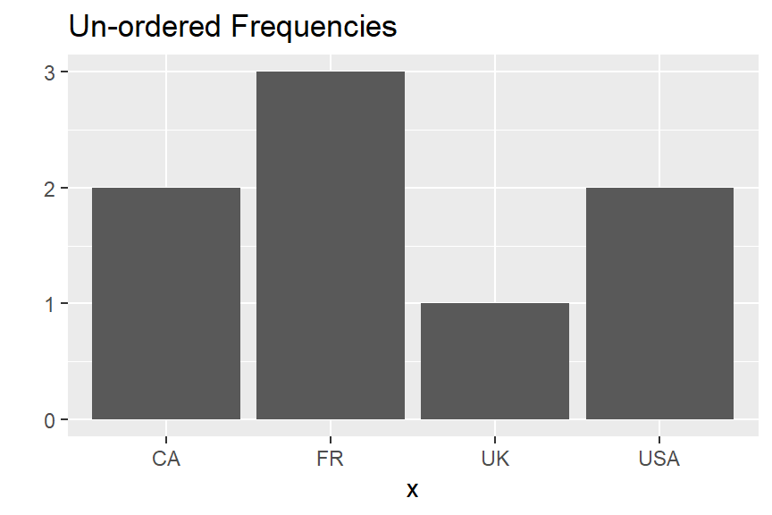

```r
library(ggplot2)
x <- as.factor(c("USA","UK","USA", "FR", "FR", "CA", "CA", "FR"))
qplot(x, main = "Un-ordered Frequencies")
```

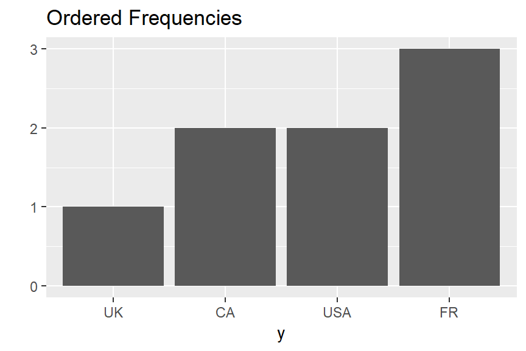

```r
## We use table to calculate frequencies, and order to sort them
ord <- order(table(x))

## "ord" contains the new ordered positions of the original levels
y <- factor(x, levels = levels(x)[ord])
qplot(y, main = "Ordered Frequencies")
```

### Changing the reference category of a factor

**Question**:

What if I just want to change the reference category for a model I’m using?

**Answer**:

By default most models consider the first level of a categorical variable to be the reference category, so you could change the reference category by changing the category ordering. Alternatively, the `relevel` function is an easy way to change the reference category within the model itself:

```r
mydata <- read.csv(file = "https://remiller1450.github.io/data/Salaries.csv")

fit1 <- lm(salary ~ sex + yrs.since.phd, data = mydata)
coef(fit1)  ## The reference group is Female
```

```
##   (Intercept)       sexMale yrs.since.phd
##    85181.8181     7923.6239      958.0793
```

```r
fit2 <- lm(salary ~ relevel(sex, ref = "Male") + yrs.since.phd, data = mydata)
coef(fit2)  ## relevel changes the reference group to Male
```

```
##                      (Intercept) relevel(sex, ref = "Male")Female
##                       93105.4419                       -7923.6239
##                    yrs.since.phd
##                         958.0793
```

# Working with Objects

### Matrices versus data.frames

**Question**:

What’s the difference between a “data.frame” object and a “matrix” object?

**Answer**:

In `R` matrices must only contain variables of a single type, meaning a matrix can either be a “numeric matrix”, if all entries are numbers, or a “character matrix”, if at least one entry contains a non-numeric character. If you try to store data containing a mixture of categorical and numeric variables as a matrix everything will be coerced to character strings.

Data.frame objects are collections of variables of different types, meaning each column of a data.frame may have its own type. See the code below for an example:

```r
x <- as.factor(c("USA","UK","USA")); y <- 1:3; z <- rnorm(3)
data <- data.frame(x, y, z)
data # Notice the variables are their own type
```

```
##     x y            z
## 1 USA 1 -0.688416821
## 2  UK 2  1.220963826
## 3 USA 3 -0.006540994
```

```r
as.matrix(data) # Notice the variables are coerced to character strings
```

```
##      x     y   z
## [1,] "USA" "1" "-0.688416821"
## [2,] "UK"  "2" " 1.220963826"
## [3,] "USA" "3" "-0.006540994"
```

### When to use the $

**Question**

I’ve noticed that sometimes I can refer to a variable using just its name (ie: “var1”), but other times I need to use the `$` to access the variable (ie: “data$var1”). How do I know which is necessary?

**Answer**:

Many functions have a “data” argument that tells the function it will be working with a particular data.frame or matrix object. Once the function knows the data object you only need to provide the variable names. If you are not using a function with a “data” argument you will have to use the `$` to access a variable.

**Example**:

```r
mydata <- read.csv(file = "https://remiller1450.github.io/data/HappyPlanet.csv")

## The lm function has a data argument, so we can later refer to variables by name
lm(data = mydata, Happiness ~ LifeExpectancy)
```

```
##
## Call:
## lm(formula = Happiness ~ LifeExpectancy, data = mydata)
##
## Coefficients:
##    (Intercept)  LifeExpectancy
##        -1.1037          0.1035
```

```r
## If we don't use the data argument we still can reach the same result using the $
lm(mydata$Happiness ~ mydata$LifeExpectancy)
```

```
##
## Call:
## lm(formula = mydata$Happiness ~ mydata$LifeExpectancy)
##
## Coefficients:
##           (Intercept)  mydata$LifeExpectancy
##               -1.1037                 0.1035
```

### Lists

**Question**:

What is a “list”? How do I access items stored as a list?

**Answer**:

Lists are type of object which contain other objects that may be of differing types or sizes. Functions which produce a lot of different outputs typically store their results as a list (see the example below). Elements of a list can be accessed using the `$` operator, or using indices within double brackets, for example: `[[1]]`. You can find out the elements of a list using the `ls` function (see the example below).

**Example**:

```r
mydata <- read.csv(file = "https://remiller1450.github.io/data/HappyPlanet.csv")
mymodel <- lm(data = mydata, Happiness ~ LifeExpectancy + Footprint)

## Print the object names within "mymodel"
ls(mymodel)
```

```
##  [1] "assign"        "call"          "coefficients"  "df.residual"
##  [5] "effects"       "fitted.values" "model"         "qr"
##  [9] "rank"          "residuals"     "terms"         "xlevels"
```

```r
## Access the coefficients
mymodel$coefficients
```

```
##    (Intercept) LifeExpectancy      Footprint
##    -0.41918926     0.08789561     0.13047538
```

```r
## Access the coefficients using an index
mymodel[[1]]
```

```
##    (Intercept) LifeExpectancy      Footprint
##    -0.41918926     0.08789561     0.13047538
```

```r
## Lists can be composed of any type of object, so you can have a list within a list
str(mymodel$qr)
```

```
## List of 5
##  $ qr   : num [1:143, 1:3] -11.9583 0.0836 0.0836 0.0836 0.0836 ...
##   ..- attr(*, "dimnames")=List of 2
##   .. ..$ : chr [1:143] "1" "2" "3" "4" ...
##   .. ..$ : chr [1:3] "(Intercept)" "LifeExpectancy" "Footprint"
##   ..- attr(*, "assign")= int [1:3] 0 1 2
##  $ qraux: num [1:3] 1.08 1.02 1.05
##  $ pivot: int [1:3] 1 2 3
##  $ tol  : num 1e-07
##  $ rank : int 3
##  - attr(*, "class")= chr "qr"
```

```r
mymodel$qr$rank
```

```
## [1] 3
```

### Using only certain rows

**Question**:

I only want to use specific rows of an object, what should I do?

**Answer**:

There are several ways to subset an object:

1. Using indices (possibly with the `which` function)
2. Using a logical condition
3. Using the `filter` function in the `dplyr` package

**Examples**:

```r
mydata <- read.csv(file = "https://remiller1450.github.io/data/HappyPlanet.csv")

##### Select only countries in region 1
## Method 1
region1A <- mydata[which(mydata$Region == 1), ]

## Method 2
region1B <- mydata[mydata$Region == 1, ]

## Method 3
library(dplyr)
region1C <- filter(mydata, Region == 1)
```

### Error when using “filter”

**Question**:

I’ve tried using the `filter` function but I always get error, even when I try to run code that I copy-pasted directly from the lab. What is going wrong?

**Answer**:

This error stems from two different functions named “filter” existing your `R` environment. You can avoid it by explicitly referencing which function you want to use via the `::` operator (see the example below). The order in which you load packages determines which filter function gets called by default, so if you load the `dplyr` package last it’s function will mask any other functions named “filter” (including the base `R` function).

**Example**:

```r
mydata <- read.csv(file = "https://remiller1450.github.io/data/HappyPlanet.csv")
library(dplyr)

filterdata <- filter(mydata, Region == 1) ## This might produce an error if you don't load dplyr
filterdata2 <- dplyr::filter(mydata, Region == 1)  ## This won't procude an error
```

# The `%>%` symbol

### What is `%>%` doing?

**Question**:

I’ve been looking at some `R` code examples online and a lot of them include `%>%`, what is going on?

**Answer**:

The pipe operator, `%>%`, is commonly used with many packages including `tidyr` and `dplyr`. The operator is designed to streamline your code, it works by passing the object or function output to the left of the pipe as the first argument into the function on the right of the pipe. Several pipes can be used to sequentially pass along output, the example below uses the `filter`, `group_by`, and `summarize` functions:

```r
data <- read.csv("https://remiller1450.github.io/data/CollegeData.csv")
library(dplyr)
results <- data %>% filter(REGION == 4) %>% group_by(STABBR) %>% summarize(avg_cost = mean(COSTT4_A))
print(results)
```

```
## # A tibble: 5 x 2
##   STABBR avg_cost
##   <fct>     <dbl>
## 1 IA       51918.
## 2 MN       43167.
## 3 MO       31882.
## 4 ND       14720
## 5 NE       42410
```

In this example, the `filter` function takes in the object `data` as its first argument and outputs only colleges with `REGION == 4`. This output is supplied as the first argument to the `group_by` function. The aggregated data output by the `group_by` function is supplied to the `summarize` function, which outputs the mean 4-year cost of colleges by state, which get stored in the object `result`.

### Should I use piping?

**Question**:

Should I use the `%>%` operator in my code?

**Answer**:

It is up to you whether or not you choose to use piping, there are many professionals that use piping, and many professionals that don’t. An advantage of piping is that it enables code with fewer redundancies and fewer intermediate objects clogging up your R environment. A disadvantage is that the pipe operator is only compatible with certain functions (mostly those in the [tidyverse](https://www.tidyverse.org/)), so you can’t use it for everything.

# R Markdown

### R Markdown vs. R scripts

**Question**:

When should I use R Markdown and when should I use a regular R script?

**Answer**:

R Markdown is a publishing extension, so you should use it when your goal is to generate reproducible results, including graphs, tables, documents, and presentations. If you are focused on exploration or cleaning your data it is usually easier to work in an R script, and later move relevant code to R Markdown once you’ve determined which products of your analysis will be shared.

### Supressing Messages

**Question**:

My R Markdown file contains printed messages from the functions I used. How can I stop these messages from appearing in my document/presentation?

**Answer**:

Use the option `error = FALSE` to supress error messages generated by code, use `warning = FALSE` to supress warning messages, and use `message = FALSE` to supress printed messages generated by code.

**Example**:

````
```{r, warning = FALSE, message = FALSE}
library(locfdr)
locfdr(rnorm(50))
```
````

### Figure Options

**Question**:

How can I change the size of figures in R Markdown output?

**Answer**:

Use the options `fig.height` or `fig.width` in the code chunk that generates your figure (see the example below).

**Example**:

````
```{r, fig.height = 4, fig.width = 5}
ggplot(...)
```
````

### Global Options

**Question**:

Do I need to add options to each individual code chunk? Is there a way that I can define options to be used everywhere?

**Answer**:

Most .Rmd files begin with a setup chunk appearing after the header. This chunk might look like:

````
```{r setup, include=FALSE}
knitr::opts_chunk$set(echo = FALSE, message = FALSE, warning = FALSE)
```
````

In this example, the options `echo = FALSE`, `message = FALSE`, and `warning = FALSE` are used by default in all code chunks appearing in the file. These defaults are overriden by any options specified in an indvidual code chunk.

### Why won’t my .Rmd file knit?

**Question**:

When I click the “Knit” button I get an error. Why won’t my .Rmd file knit?

**Answer**:

There are countless reasons why you might encounter an error when knitting an .Rmd file. Here are a few of the common ones:

1. You have objects that are defined out of order - R Markdown runs your code in order from scratch, which is not how most people work when exploring a dataset in an R Script
2. You didn’t wrap all of your `R` code in chunks opened by ```{r} and closed by ```
3. You gave the same label to multiple code chunks - ```{r MyName} will label that chunk “MyName”, but you can’t use this label for any other chunks
4. You used the `install.packages` function - you should always comment out this command after using it once
5. You used the `View` function - you should remove this, if you want to see your data in the output document use the `print` or `kable` functions
6. You didn’t include `library` commands for all of the packages you used - again, R Markdown runs your code from scratch, so you need to load your libraries everytime you knit